# *Sphagnum* Conditioned Microbiome Data and Figures

Alyssa Carrell

1/15/2019

# Introduction

The use of microbiomes to select for specific plant host phenotypic response to environment have been demonstrated in recent studies. However, the underlying mechanisms for microbial mediated plant phenotypic response is unknown. Here we explore the mechanisms for microbial mediated host tolerance of elevated temperature. Microbiomes conditioned to ambient or elevated temperature were applied to moss and subjected to ambient or elevated temperatures. Fluorcam measurements were performed each week and the experiment was harvested at 4 weeks to assess plant growth and microbiome composition.

# Experimental details

**Experiment Start Date**  
Experiment 1 - performed 2016  
Experiment 2 - performed 2017

**Duration**  
Experiment 1 - 4 weeks  
Experiment 2 - 3 weeks

**Measurements taken**  
Experiment 1 - Fluorcam weekly, area growth, 16S profile, RNA not extractable, pH measured  
Experiment 2 - Fluorcam weekly, area growth, 16S profile, RNAseq, final pH, 15N and ARA

**Methods** Adapted microbe extraction and inoculation From each treatment, 100 g of tissue was diced with sterile razor blade and pulverized in BG11 -N, pH 5.5 with a mortar and pestle. The resulting suspension was filtered through Mira Cloth and stored at 4 C until application. The microbes were then pelleted and resuspended in BG11 -N medium (pH5.5). A single capitula of axenic Sphagnum fallax was added to each well of a 12 well plate and inoculated with 2 ml of +0 microbiome, +9 microbiome, or sterile media. Warming conditions were determined from the 2016 summer season temperatures

# Packages

```r
library(tidyverse)
library(car)
library(rcompanion)
library(FSA)
library(agricolae)
library(reshape2)
library(plotrix)
```

# Experiment 1

## Summary Statistics

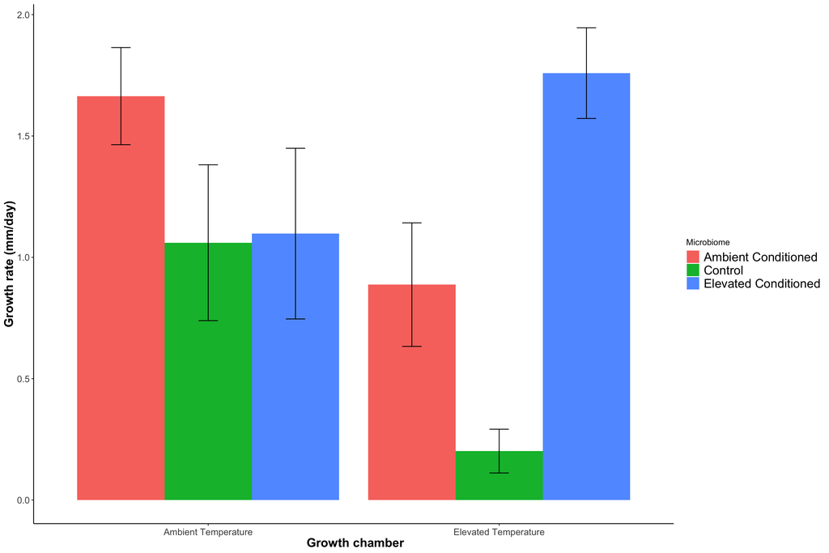

Fig. 1: Growth rate of conditioned microbiome 2016

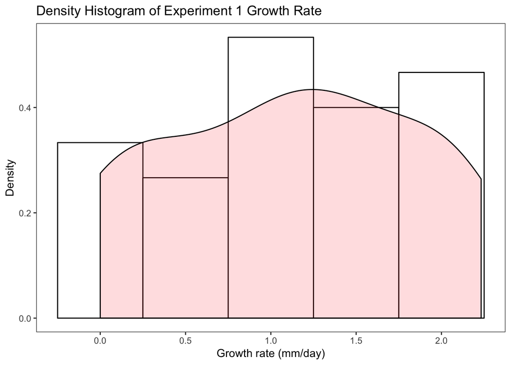

## Rank Transform

```r
exp1.rank <- rank(Exp1$Growth.rate.mmperday)

# binding transform
Exp1 <- cbind(Exp1, exp1.rank)

# two-way ANOVA with ranked data
ranked.exp1.aov <- aov(exp1.rank ~ Chamber + Microbe + Chamber:Microbe , data = Exp1)
Anova(ranked.exp1.aov, type = 3)
```

|  | Sum Sq | Df | F value | Pr(>F) |
| --- | --- | --- | --- | --- |
| (Intercept) | 2420.0000 | 1 | 53.225806 | 1.549760e-07 |
| Chamber | 211.6000 | 1 | 4.653959 | 4.121053e-02 |
| Microbe | 170.5333 | 2 | 1.875367 | 1.750819e-01 |
| Chamber:Microbe | 516.4667 | 2 | 5.679619 | 9.560931e-03 |
| Residuals | 1091.2000 | 24 | NA | NA |

```r
TukeyHSD(ranked.exp1.aov)
```

```
##   Tukey multiple comparisons of means
##     95% family-wise confidence level
##
## Fit: aov(formula = exp1.rank ~ Chamber + Microbe + Chamber:Microbe, data = Exp1)
##
## $Chamber
##            diff       lwr      upr     p adj
## ET-AT -3.533333 -8.614977 1.548311 0.1641758
##
## $Microbe
##            diff        lwr        upr     p adj
## Control-AC -7.8 -15.330608 -0.2693921 0.0413468
## EC-AC       2.1  -5.430608  9.6306079 0.7678500
## EC-Control  9.9   2.369392 17.4306079 0.0084967
##
## $`Chamber:Microbe`
##                        diff        lwr       upr     p adj
## ET:AC-AT:AC            -9.2 -22.385796  3.985796 0.2933802
## AT:Control-AT:AC       -7.6 -20.785796  5.585796 0.4949848
## ET:Control-AT:AC      -17.2 -30.385796 -4.014204 0.0057197
## AT:EC-AT:AC            -6.6 -19.785796  6.585796 0.6385347
## ET:EC-AT:AC             1.6 -11.585796 14.785796 0.9989007
## AT:Control-ET:AC        1.6 -11.585796 14.785796 0.9989007
## ET:Control-ET:AC       -8.0 -21.185796  5.185796 0.4398671
## AT:EC-ET:AC             2.6 -10.585796 15.785796 0.9892763
## ET:EC-ET:AC            10.8  -2.385796 23.985796 0.1541977
## ET:Control-AT:Control  -9.6 -22.785796  3.585796 0.2523661
## AT:EC-AT:Control        1.0 -12.185796 14.185796 0.9998890
## ET:EC-AT:Control        9.2  -3.985796 22.385796 0.2933802
## AT:EC-ET:Control       10.6  -2.585796 23.785796 0.1680561
## ET:EC-ET:Control       18.8   5.614204 31.985796 0.0022945
## ET:EC-AT:EC             8.2  -4.985796 21.385796 0.4132882
```

```r
# compact letter displays
tx <- with(Exp1, interaction(Chamber, Microbe))
amod <- aov(exp1.rank ~ tx, data = Exp1)
groups <- HSD.test(amod, "tx", group = TRUE)
groups
```

```
## $statistics
##    MSerror Df Mean       CV     MSD
##   45.46667 24 15.5 43.50256 13.1858
##
## $parameters
##    test name.t ntr StudentizedRange alpha
##   Tukey     tx   6         4.372651  0.05
##
## $means
##            exp1.rank      std r Min Max Q25 Q50 Q75
## AT.AC           22.0 5.567764 5  15  27  17  25  26
## AT.Control      14.4 8.443933 5   6  24   9  10  23
## AT.EC           15.4 8.876936 5   4  28  12  14  19
## ET.AC           12.8 7.328028 5   2  22  11  13  16
## ET.Control       4.8 2.774887 5   2   8   2   5   7
## ET.EC           23.6 5.504544 5  18  30  20  21  29
##
## $comparison
## NULL
##
## $groups
##            exp1.rank groups
## ET.EC           23.6      a
## AT.AC           22.0      a
## AT.EC           15.4     ab
## AT.Control      14.4     ab
## ET.AC           12.8     ab
## ET.Control       4.8      b
##
## attr(,"class")
## [1] "group"
```

Growth data was rank transformed prior to performing a standard two-way ANOVA. Growth rate in each chamber was dependant on microbial community (p < 0.01). Within the Ambient Temperature (AT) chamber there were no differences in moss growth rate among the three microbial treatments. Growth rate of moss inoculated with an Ambient Temperature Conditioned microbiome (AC) did not differ from the control or moss inoculated with an Elevated Temperature Conditioned microbiome (EC). However, within the Elevated Temperature (ET) chamber, moss growth rate was significantly different between EC and control (p < 0.01). Moss grown with AC and the control had relatively similar growth rates, suggesting that changes in growth rate are not simply due to having a microbiome. Rather, the advantage does appear to be driven by a microbiome pre-adapted to elevated temperatures.

## QY

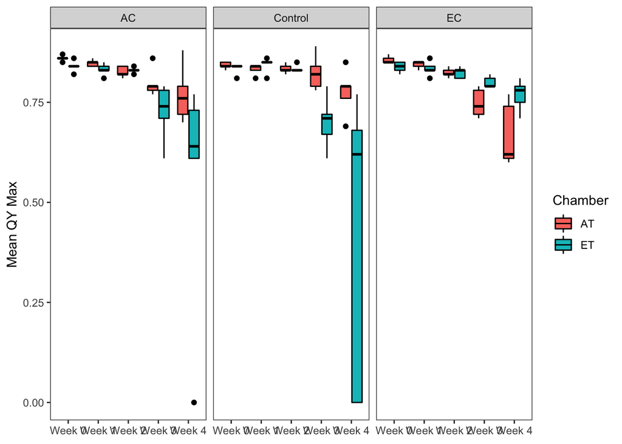

```r
exp1.qy <- Exp1 %>%
  select(Chamber, Microbe, QY_max.4, QY_max.3, QY_max.2, QY_max.1, QY_max.0) %>%
  melt(id = c("Chamber", "Microbe"))

ggplot(data = exp1.qy, aes(x = variable, y = value, fill = Chamber)) + geom_boxplot(colour = "black") + facet_grid(. ~ Microbe) + scale_x_discrete(limits = c("QY_max.0", "QY_max.1", "QY_max.2", "QY_max.3", "QY_max.4"), labels = c("Week 0", "Week 1", "Week 2", "Week 3", "Week 4")) + ylab("Mean QY Max") + theme_bw() + theme(panel.grid.major = element_blank(), panel.grid.minor = element_blank()) + theme(axis.title.x = element_blank())
```

### Week 0

```r
wk0.sum <- Exp1 %>%
  dplyr::select(Sample, Chamber, Microbe, QY_max.0) %>%
  group_by(Chamber, Microbe) %>%
  summarise(
    n = n(),
    mean = mean(QY_max.0),
    sd = sd(QY_max.0),
    se = ((sd(QY_max.0))/sqrt(n))
  )
```

### Week 1

```r
wk1.sum <- Exp1 %>%
  select(Sample, Chamber, Microbe, QY_max.1) %>%
  group_by(Chamber, Microbe) %>%
  summarise(
    n = n(),
    mean = mean(QY_max.1),
    sd = sd(QY_max.1),
    se = ((sd(QY_max.1))/sqrt(n))
  )
```

### Week 2

```r
wk2.sum <- Exp1 %>%
  select(Sample, Chamber, Microbe, QY_max.2) %>%
  group_by(Chamber, Microbe) %>%
  summarise(
    n = n(),
    mean = mean(QY_max.2),
    sd = sd(QY_max.2),
    se = ((sd(QY_max.2))/sqrt(n))
  )
```

### Week 3

```r
wk3.sum <- Exp1 %>%
  select(Sample, Chamber, Microbe, QY_max.3) %>%
  group_by(Chamber, Microbe) %>%
  summarise(
    n = n(),
    mean = mean(QY_max.3),
    sd = sd(QY_max.3),
    se = ((sd(QY_max.3))/sqrt(n))
  )
```

### Week 4

```r
wk4.sum <- Exp1 %>%
  select(Sample, Chamber, Microbe, QY_max.4) %>%
  group_by(Chamber, Microbe) %>%
  summarise(
    n = n(),
    mean = mean(QY_max.4, na.rm = TRUE),
    sd = sd(QY_max.4, na.rm = TRUE),
    se = ((sd(QY_max.4, na.rm = TRUE))/sqrt(n))
  )
```

## Mortality

Mortality rate is usually expressed as **death** in a defined **population** during a specified **interval**. In this case, we do not necessarily have individual death per day or per each week. Therefore, percent loss of fluorescence from Week 0 QY will be used as proxy to represent moss death as the treatment continues.

Note: decided to calculate percet of fluorscence left (100% - percent lost) at the end of each week instead of purely percet loss to show a declining graph instead of an increasing graph which could be more confusing to interpret.

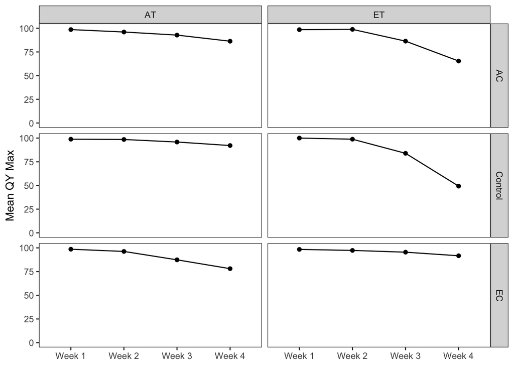

```r
# isolating just the QY data
# calculating percent left (100% - percent loss)
exp1.qy.left <- Exp1 %>%
  dplyr::select(Chamber, Microbe, QY_max.1, QY_max.2, QY_max.3, QY_max.4, QY_max.0) %>%
  mutate(percent_left1 = (100 - (((QY_max.0 - QY_max.1)/QY_max.0)*100))) %>%
  mutate(percent_left2 = (100 - (((QY_max.0 - QY_max.2)/QY_max.0)*100))) %>%
  mutate(percent_left3 = (100 - (((QY_max.0 - QY_max.3)/QY_max.0)*100))) %>%
  mutate(percent_left4 = (100 - (((QY_max.0 - QY_max.4)/QY_max.0)*100)))

# summary percent left
# make this into a table
qyleft.summary <- exp1.qy.left %>%
  select(Chamber, Microbe, percent_left1, percent_left2,percent_left3, percent_left4) %>%
   group_by(Chamber, Microbe) %>%
   summarise_all(funs(mean, sd, std.error))

# preparation for plotting
exp1.qy.prep <- exp1.qy.left %>%
  dplyr::select(Chamber, Microbe, percent_left1, percent_left2,percent_left3, percent_left4) %>%
  melt(id = c("Chamber", "Microbe"))


# mean over time
ggplot(data = exp1.qy.prep, aes(x = variable, y = value,group=1)) + geom_point(stat = 'summary', fun.y=mean) + stat_summary(fun.y = mean, geom = "line") + facet_grid(Microbe ~ Chamber) + scale_x_discrete(limits = c("percent_left1", "percent_left2","percent_left3", "percent_left4"), labels = c("Week 1", "Week 2", "Week 3", "Week 4")) + ylab("Mean QY Max") + theme_bw() + theme(panel.grid.major = element_blank(), panel.grid.minor = element_blank()) + theme(axis.title.x = element_blank()) + scale_y_continuous(limits = c(0, 100))
```

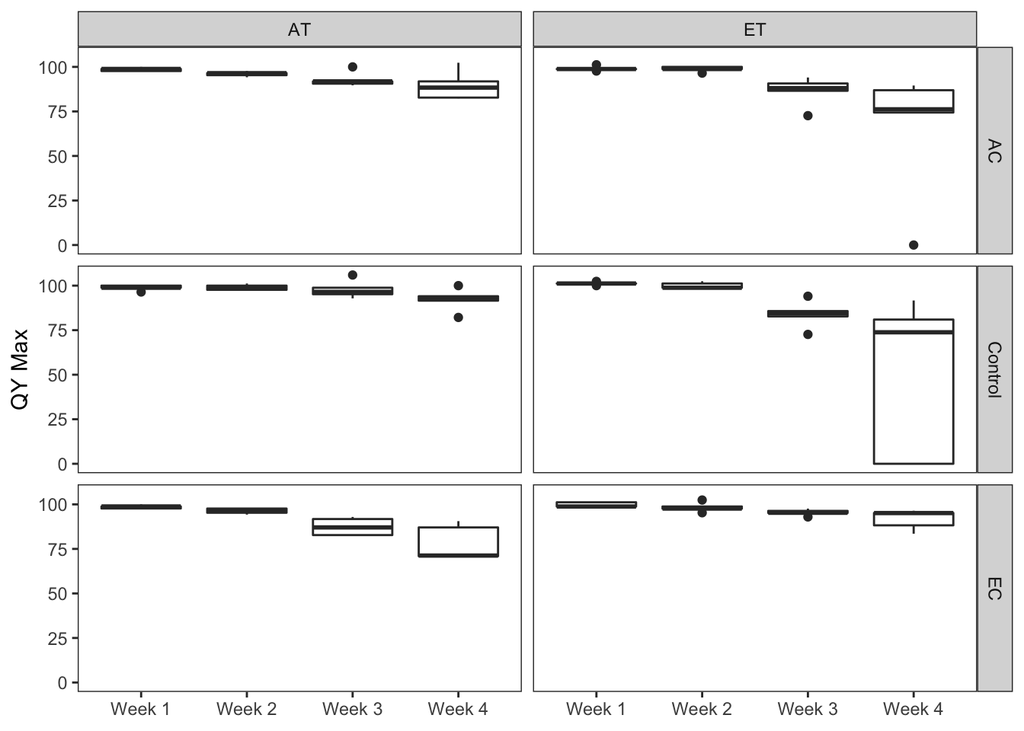

```r
# boxplot over time
ggplot(data = exp1.qy.prep, aes(x = variable, y = value)) + geom_boxplot() + facet_grid(Microbe ~ Chamber) + scale_x_discrete(limits = c("percent_left1", "percent_left2","percent_left3", "percent_left4"), labels = c("Week 1", "Week 2", "Week 3", "Week 4")) + ylab("QY Max") + theme_bw() + theme(panel.grid.major = element_blank(), panel.grid.minor = element_blank()) + theme(axis.title.x = element_blank())
```

```r
# setting up dataframe
exp1.qy.manova <- exp1.qy.left %>%
  select(Chamber, Microbe, percent_left1, percent_left2, percent_left3, percent_left4) %>%
  melt(id = c("Chamber", "Microbe"))
exp1.qy.manova$ID <- seq.int(nrow(exp1.qy.manova))

# rank transforming percentage data
qy1.rank <- rank(exp1.qy.manova$value)
exp1.qy.manova  <- cbind(exp1.qy.manova, qy1.rank)

# establishing factors
exp1.qy.manova <- within(exp1.qy.manova, {
  Chamber <- factor(Chamber)
  Microbe <- factor(Microbe)
  variable <- factor(variable)
})

# means
exp1.qymanova.sum <- exp1.qy.manova %>%
  group_by(Chamber, Microbe, variable) %>%
  summarise(mean = mean(value))

# ANOVA
qy1.left.aov <- with(exp1.qy.manova,
               aov(qy1.rank ~ variable*Chamber*Microbe + Error(ID / (Chamber*Microbe))))
summary(qy1.left.aov)
```

```
##
## Error: ID
##          Df Sum Sq Mean Sq
## variable  1  70482   70482
##
## Error: ID:Chamber
##          Df Sum Sq Mean Sq
## variable  1  367.8   367.8
##
## Error: ID:Microbe
##          Df Sum Sq Mean Sq
## variable  1   3190    3190
## Chamber   1    120     120
##
## Error: ID:Chamber:Microbe
##          Df Sum Sq Mean Sq
## variable  1   1029    1029
## Chamber   1  10027   10027
##
## Error: Within
##                          Df Sum Sq Mean Sq F value   Pr(>F)
## variable                  3  14228    4743  12.550 6.29e-07 ***
## Chamber                   1    158     158   0.418    0.520
## Microbe                   2    749     375   0.991    0.375
## variable:Chamber          3   2355     785   2.077    0.109
## variable:Microbe          6   2087     348   0.920    0.484
## Chamber:Microbe           2   1466     733   1.939    0.150
## variable:Chamber:Microbe  6   3511     585   1.548    0.172
## Residuals                90  34013     378
## ---
## Signif. codes:  0 '***' 0.001 '**' 0.01 '*' 0.05 '.' 0.1 ' ' 1
```

Source code: https://datascienceplus.com/two-way-anova-with-repeated-measures/ https://biostats.w.uib.no/factorial-repeated-measures-anova-two-way-repeated-measures-anova/ https://stats.stackexchange.com/questions/264171/how-to-do-two-way-repeated-measures-anova-using-aov-in-r validate with: https://www.r-bloggers.com/r-tutorial-series-two-way-repeated-measures-anova/ if time

# Experiment 2

## Summary Statistics

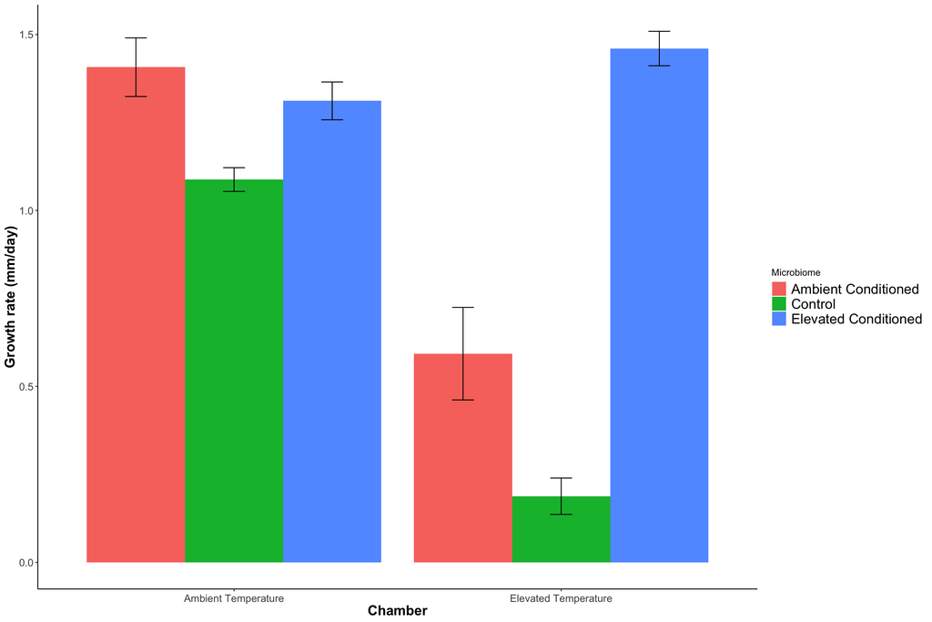

Fig. 2: Growth rate of conditioned microbiome 2017

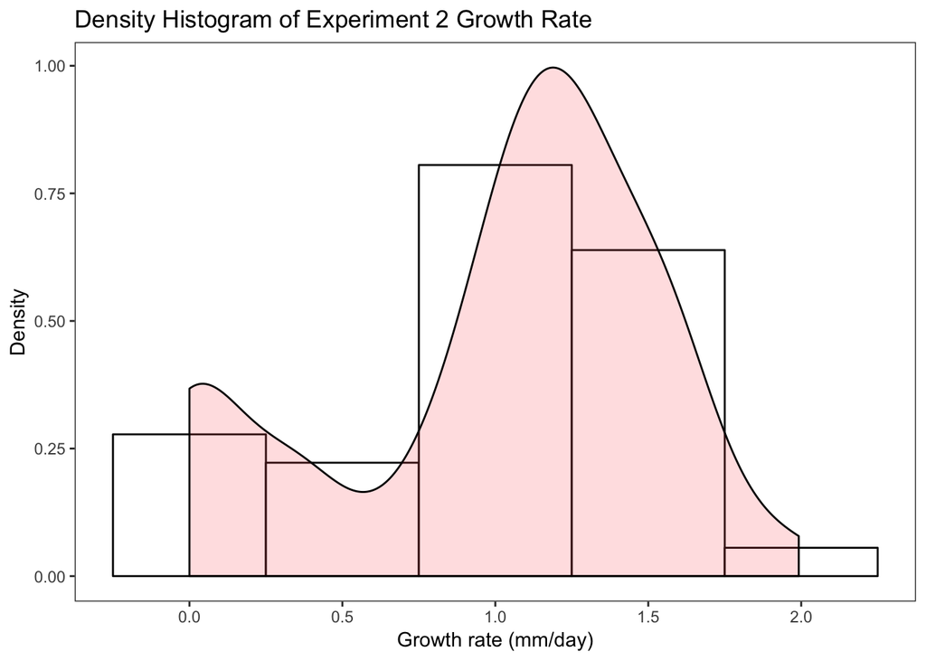

Differences in moss growth rate were based on the influence of microbial treatments in the chambers (p <0.001). Within the ambient temperature chamber (AT), moss grown with AC and moss grown with EC increased growth rate relative to the control (p < 0.05). However, there were no differences in growth between AC and EC suggesting that under ambient temperature, microbial inoculation increases growth irregardless of microbial community diversity.

Elevated temperatures differentiated the influence of the microbial community on moss growth rate. Moss inoculated with a microbial community conditioned in elevated temperatures had high rates of growth despite elevated temperatures with respect to moss grown with ambient conditioned microbiomes (AC) and the control (p < 0.001). Furthermore, AC moss and control moss did not differ in growth rate suggesting that it is specifically a pre-adapted microbiome that imparts moss with the capacity to tolerate elevated temperatures.

When comparing microbial treatments across chambers, it is apparent that elevated temperatures severely decreased growth of moss with AC and moss control. Only moss inoculated with EC showed no difference in growth regardless of ambient or elevated temperatures. This indicates that the presence of microbial members capable of surviving in elevated temperatures is generally beneficial, but is especially critical in rising temperatures.

## Rank Transform

```r
exp2.rank <- rank(Exp2$Growth.rate.mmperday)

# binding transform
Exp2 <- cbind(Exp2, exp2.rank)

# two-way ANOVA with ranked data
ranked.exp2.aov <- aov(exp2.rank ~ Chamber + Microbe + Chamber:Microbe , data = Exp2)
Anova(ranked.exp2.aov, type = 3)
```

|  | Sum Sq | Df | F value | Pr(>F) |
| --- | --- | --- | --- | --- |
| (Intercept) | 32865.333 | 1 | 308.44840 | 1.426546e-26 |
| Chamber | 7632.667 | 1 | 71.63426 | 3.922804e-12 |
| Microbe | 2476.500 | 2 | 11.62125 | 4.743327e-05 |
| Chamber:Microbe | 6822.583 | 2 | 32.01572 | 1.911404e-10 |
| Residuals | 7032.333 | 66 | NA | NA |

```r
TukeyHSD(ranked.exp2.aov)
```

```
##   Tukey multiple comparisons of means
##     95% family-wise confidence level
##
## Fit: aov(formula = exp2.rank ~ Chamber + Microbe + Chamber:Microbe, data = Exp2)
##
## $Chamber
##            diff      lwr       upr p adj
## ET-AT -16.16667 -21.0243 -11.30903     0
##
## $Microbe
##                 diff       lwr       upr     p adj
## Control-AC -13.04167 -20.18634 -5.896992 0.0001288
## EC-AC       19.04167  11.89699 26.186341 0.0000001
## EC-Control  32.08333  24.93866 39.228008 0.0000000
##
## $`Chamber:Microbe`
##                             diff        lwr        upr     p adj
## ET:AC-AT:AC           -35.666667 -48.035372 -23.297961 0.0000000
## AT:Control-AT:AC      -19.250000 -31.618705  -6.881295 0.0003091
## ET:Control-AT:AC      -42.500000 -54.868705 -30.131295 0.0000000
## AT:EC-AT:AC            -4.000000 -16.368705   8.368705 0.9319339
## ET:EC-AT:AC             6.416667  -5.952039  18.785372 0.6511149
## AT:Control-ET:AC       16.416667   4.047961  28.785372 0.0030445
## ET:Control-ET:AC       -6.833333 -19.202039   5.535372 0.5875372
## AT:EC-ET:AC            31.666667  19.297961  44.035372 0.0000000
## ET:EC-ET:AC            42.083333  29.714628  54.452039 0.0000000
## ET:Control-AT:Control -23.250000 -35.618705 -10.881295 0.0000090
## AT:EC-AT:Control       15.250000   2.881295  27.618705 0.0072775
## ET:EC-AT:Control       25.666667  13.297961  38.035372 0.0000009
## AT:EC-ET:Control       38.500000  26.131295  50.868705 0.0000000
## ET:EC-ET:Control       48.916667  36.547961  61.285372 0.0000000
## ET:EC-AT:EC            10.416667  -1.952039  22.785372 0.1475808
```

```r
# compact letter displays
tx <- with(Exp2, interaction(Chamber, Microbe))
amod <- aov(exp2.rank ~ tx, data = Exp2)
groups <- HSD.test(amod, "tx", group = TRUE)
groups
```

```
## $statistics
##    MSerror Df Mean       CV      MSD
##   106.5505 66 36.5 28.28036 12.36871
##
## $parameters
##    test name.t ntr StudentizedRange alpha
##   Tukey     tx   6         4.150851  0.05
##
## $means
##            exp2.rank       std  r  Min Max   Q25   Q50   Q75
## AT.AC      52.333333 13.357554 12 31.0  72 43.00 52.50 60.50
## AT.Control 33.083333  9.452833 12 22.0  52 26.50 30.50 37.75
## AT.EC      48.333333 12.455983 12 30.0  67 38.50 48.00 58.50
## ET.AC      16.666667 10.493144 12  4.5  38  4.50 18.25 21.50
## ET.Control  9.833333  4.396969 12  4.5  16  4.50 10.50 13.25
## ET.EC      58.750000  9.323723 12 45.0  70 50.25 62.00 66.50
##
## $comparison
## NULL
##
## $groups
##            exp2.rank groups
## ET.EC      58.750000      a
## AT.AC      52.333333      a
## AT.EC      48.333333      a
## AT.Control 33.083333      b
## ET.AC      16.666667      c
## ET.Control  9.833333      c
##
## attr(,"class")
## [1] "group"
```

## QY

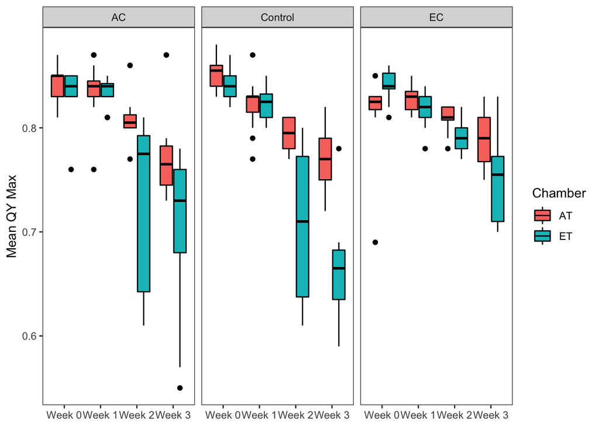

```r
exp2.qy <- Exp2 %>%
  select(Chamber, Microbe, QY_max.3, QY_max.2, QY_max.1, QY_max.0) %>%
  melt(id = c("Chamber", "Microbe"))

ggplot(data = exp2.qy, aes(x = variable, y = value, fill = Chamber)) + geom_boxplot(colour = "black") + facet_grid(. ~ Microbe) + scale_x_discrete(limits = c("QY_max.0", "QY_max.1", "QY_max.2", "QY_max.3"), labels = c("Week 0", "Week 1", "Week 2", "Week 3", "Week 4")) + ylab("Mean QY Max") + theme_bw() + theme(panel.grid.major = element_blank(), panel.grid.minor = element_blank()) + theme(axis.title.x = element_blank())
```

### Week 0

### Week 1

### Week 2

### Week 3

## Mortality

Question, why the NAs? Were those dead or just not measured?

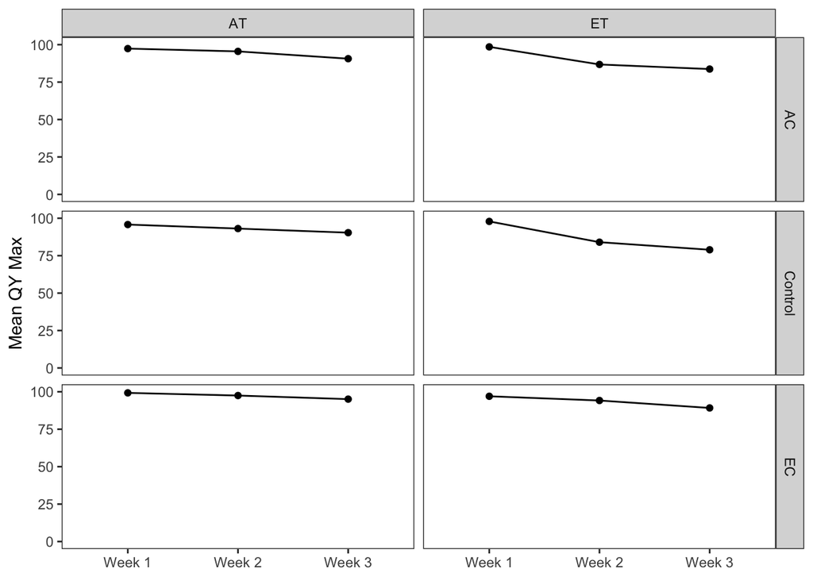

```r
# isolating just the QY data
# calculating percent left (100% - percent loss)
exp2.qy.left <- Exp2 %>%
  dplyr::select(Sample, Chamber, Microbe, QY_max.1, QY_max.2, QY_max.3, QY_max.0) %>%
  mutate(percent_left1 = (100 - (((QY_max.0 - QY_max.1)/QY_max.0)*100))) %>%
  mutate(percent_left2 = (100 - (((QY_max.0 - QY_max.2)/QY_max.0)*100))) %>%
  mutate(percent_left3 = (100 - (((QY_max.0 - QY_max.3)/QY_max.0)*100)))

# summary percent left
# make this into a table
exp2.qyleft.sum <- exp2.qy.left %>%
  select(Chamber, Microbe, percent_left1, percent_left2,percent_left3) %>%
   group_by(Chamber, Microbe) %>%
   summarise_all(funs(mean, sd, std.error))

# prep for plotting percent left
exp2.qy.prep <- exp2.qy.left %>%
  dplyr::select(Chamber, Microbe, percent_left1, percent_left2, percent_left3)  %>%
  melt(id = c("Chamber", "Microbe"))

# mean over time
ggplot(data = exp2.qy.prep, aes(x = variable, y = value,group=1)) + geom_point(stat = 'summary', fun.y=mean) + stat_summary(fun.y = mean, geom = "line") + facet_grid(Microbe ~ Chamber) + scale_x_discrete(limits = c("percent_left1", "percent_left2", "percent_left3"), labels = c("Week 1", "Week 2", "Week 3")) + ylab("Mean QY Max") + theme_bw() + theme(panel.grid.major = element_blank(), panel.grid.minor = element_blank()) + theme(axis.title.x = element_blank()) + scale_y_continuous(limits = c(0, 100))
```

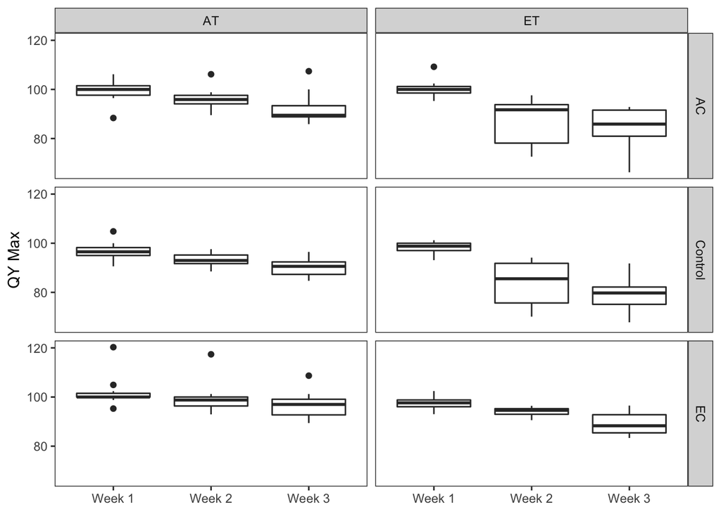

```r
# boxplot over time
ggplot(data = exp2.qy.prep, aes(x = variable, y = value)) + geom_boxplot() + facet_grid(Microbe ~ Chamber) + scale_x_discrete(limits = c("percent_left1", "percent_left2", "percent_left3"), labels = c("Week 1", "Week 2", "Week 3")) + ylab("QY Max") + theme_bw() + theme(panel.grid.major = element_blank(), panel.grid.minor = element_blank()) + theme(axis.title.x = element_blank())
```

```r
# setting up dataframe
exp2.qy.manova <- exp2.qy.left %>%
  select(Chamber, Microbe, percent_left1, percent_left2, percent_left3) %>%
  melt(id = c("Chamber", "Microbe"))
exp2.qy.manova$ID <- seq.int(nrow(exp2.qy.left))

# rank transforming percentage data
qy2.rank <- rank(exp2.qy.manova$value)
exp2.qy.manova <- cbind(exp2.qy.manova, qy2.rank)

# establishing factors
exp2.qy.manova <- within(exp2.qy.manova, {
  Chamber <- factor(Chamber)
  Microbe <- factor(Microbe)
  variable <- factor(variable)
})

# means
exp2.qymanova.sum <- exp2.qy.manova %>%
  group_by(Chamber, Microbe, variable) %>%
  summarise(mean = mean(value))

# ANOVA
qy2.left.aov <- with(exp2.qy.manova,
               aov(qy2.rank ~ variable*Chamber*Microbe + Error(ID / (Chamber*Microbe))))
summary(qy2.left.aov)
```

```
##
## Error: ID
##         Df Sum Sq Mean Sq
## Chamber  1  43610   43610
##
## Error: ID:Chamber
##         Df Sum Sq Mean Sq
## Chamber  1   1614    1614
##
## Error: ID:Microbe
##         Df Sum Sq Mean Sq
## Chamber  1     84      84
## Microbe  1   4662    4662
##
## Error: ID:Chamber:Microbe
##         Df Sum Sq Mean Sq
## Chamber  1  10030   10030
## Microbe  1  32481   32481
##
## Error: Within
##                           Df Sum Sq Mean Sq F value  Pr(>F)
## variable                   2 235724  117862  50.697 < 2e-16 ***
## Chamber                    1    155     155   0.067 0.79669
## Microbe                    2   3404    1702   0.732 0.48222
## variable:Chamber           2  27167   13584   5.843 0.00344 **
## variable:Microbe           4  18406    4601   1.979 0.09925 .
## Chamber:Microbe            2   1494     747   0.321 0.72553
## variable:Chamber:Microbe   4  13269    3317   1.427 0.22655
## Residuals                192 446368    2325
## ---
## Signif. codes:  0 '***' 0.001 '**' 0.01 '*' 0.05 '.' 0.1 ' ' 1
```